# EDS1 Experiment and Data

Chase Mateusiak, chasem@wustl.edu

2022-01-18

# Primary Questions

1. In what conditions is EDS1 expressed?
2. What is EDS1 regulated by?
3. What does EDS1 regulate?
4. How does EDS1 relate to RGT1?
5. What phenotypes associated with RGT1 deletion? (see SGD)
6. (possible) RGT1/EDS1 change/divergence over time has lead to differentiated function and therefore retention

## Hypotheses

- EDS1 responds to limited glucose conditions
- EDS1 expression is (depedent? related to?) snf1
- EDS1 has a role in the lysine pathway
- EDS1 regulates HXT and other genes regulated by RGT1/MIG1
- protein-protein interactions (sources: string, biogrid – see SGD for this, easy to click around)
- cell map – which other genes have interactions with EDS1 (may also be avail through biogrid). otherway: take two genes, compute distance between interaction vectors. Do they tend to interact with some other gene?

# RNAseq

## QC Metrics and Thresholds

| Metric | Threshold | Status |
| --- | --- | --- |
| mRNA total | 1e6 | 1 |
| mRNA percent | 75 | 2 |
| Not Aligned Total Percent | 7 | 4 |
| Deleted locus coverage | .25 | 8 |
| Deleted locus log2(norm+1) |  |  |
| Marker expression? |  |  |

### Chemostat sample distributions

#### mRNA Total Distribution

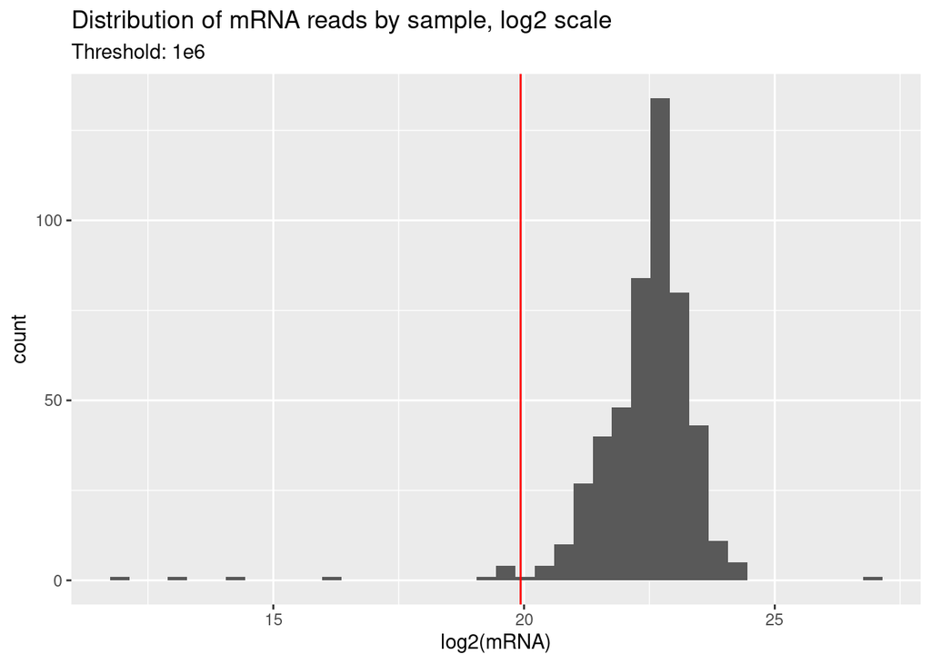

#### mRNA Percent Distribution

This reflects mRNA as a percent of uniquely mapped reads. Note the bimodal nature of the distribution. I do not yet have an explanation.

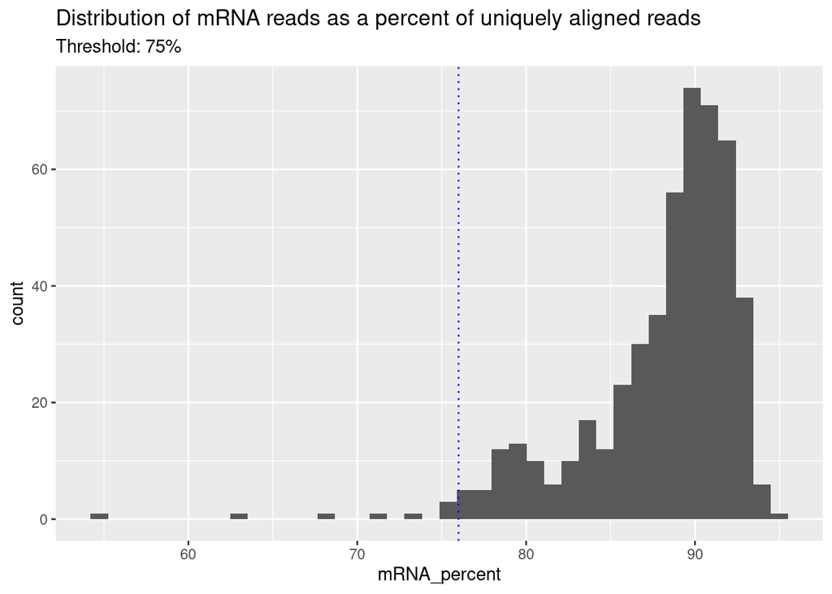

#### Deleted coverage vs log2(norm)

NOTE: points **are not** samples. A sample with 4 KO loci is represented as four points on the plots.

The x-axis represents coverage across the deleted gene CDS, and the y-axis represents expression, on a log2 scale. Expression has been scaled by library size, and transcript length normalized.

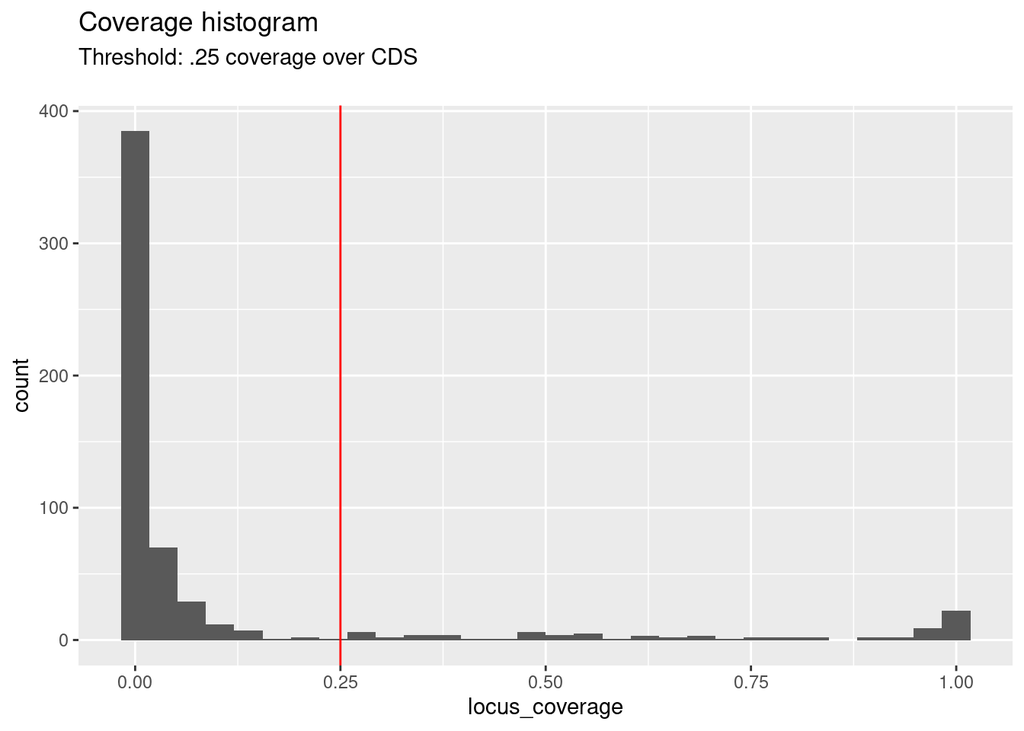

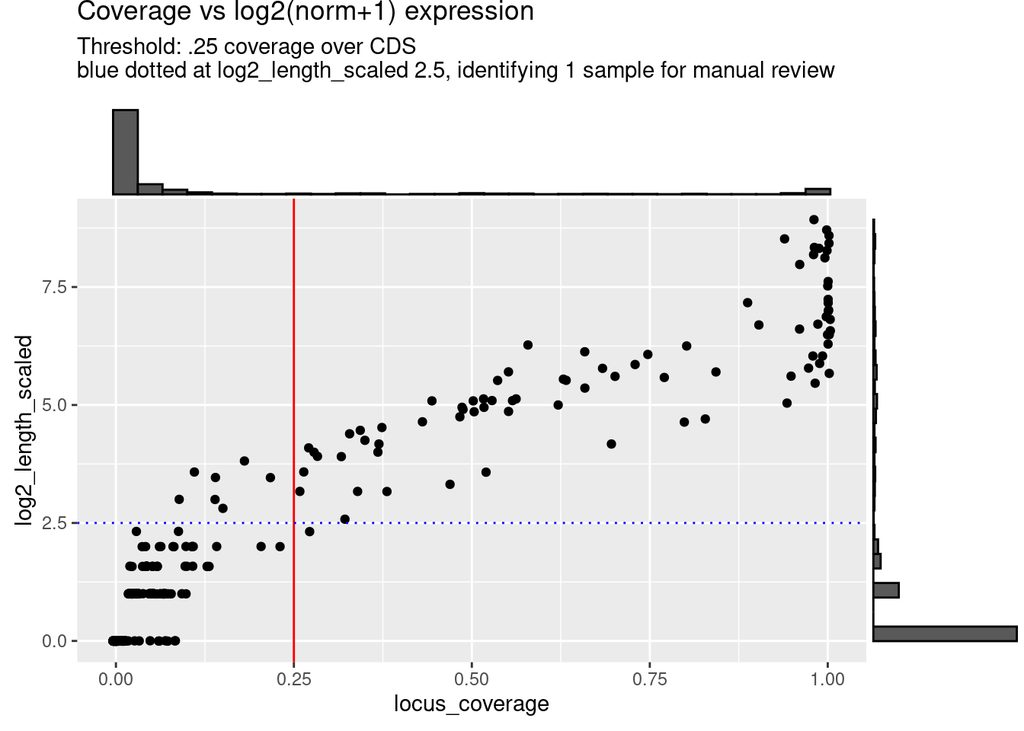

Note that despite what it appears on the plot, there are only 84 samples above the .25 threshold, and 507 samples below the threshold. The points below the threshold simply stack on top of one another.

## Replicate Tally

```r
DT::datatable(full_tally)
```

|  | condition | WT | WT_qc1 | YBR033W | YBR033W_qc1 | YBR033W_YDR034C | YBR033W_YDR034C_qc1 | YBR033W_YKL038W | YBR033W_YKL038W_qc1 | YDR034C | YDR034C_qc1 | YDR477W | YDR477W_qc1 | YGL035C | YGL035C_qc1 | YGL035C_YBR033W | YGL035C_YBR033W_qc1 | YGL035C_YGL209W_YKL038W_YBR033W | YGL035C_YGL209W_YKL038W_YBR033W_qc1 | YGL035C_YKL038W | YGL035C_YKL038W_qc1 | YGL209W | YGL209W_qc1 | YGL209W_YBR033W | YGL209W_YGL035C | YGL209W_YGL035C_qc1 | YGL209W_YKL038W | YGL209W_YKL038W_qc1 | YKL038W | … |
| --- | --- | --- | --- | --- | --- | --- | --- | --- | --- | --- | --- | --- | --- | --- | --- | --- | --- | --- | --- | --- | --- | --- | --- | --- | --- | --- | --- | --- | --- | --- |
| 1 | Minimal_HisMetLeu_Glucose_0.001_30_-1 |  |  |  |  |  |  |  |  |  |  |  |  |  |  |  |  | 4 | 4 | 4 | 3 |  |  |  |  |  |  |  |  | … |
| 2 | Minimal_HisMetLeu_Glucose_2_30_30 |  |  |  |  |  |  |  |  |  |  |  |  |  |  |  |  | 2 | 2 | 2 | 2 |  |  |  |  |  |  |  |  | … |
| 3 | Minimal_HisMetLeu_Glucose_2_30_45 |  |  |  |  |  |  |  |  |  |  |  |  |  |  |  |  | 4 | 4 | 4 | 4 |  |  |  |  |  |  |  |  | … |
| 4 | Minimal_HisMetLeu_Glucose_2_30_60 |  |  |  |  |  |  |  |  |  |  |  |  |  |  |  |  | 4 | 4 | 4 | 3 |  |  |  |  |  |  |  |  | … |
| 5 | Minimal_HisMetLeu_Glucose_2_30_90 |  |  |  |  |  |  |  |  |  |  |  |  |  |  |  |  | 4 | 4 | 4 | 4 |  |  |  |  |  |  |  |  | … |
| 6 | Minimal_HisMetLeu_Glucose_2_30_180 |  |  |  |  |  |  |  |  |  |  |  |  |  |  |  |  | 4 | 4 | 4 | 4 |  |  |  |  |  |  |  |  | … |
| 7 | Minimal_HisMetLeu_Glucose_2_30_300 |  |  |  |  |  |  |  |  |  |  |  |  |  |  |  |  | 4 | 4 | 4 | 4 |  |  |  |  |  |  |  |  | … |
| 8 | Minimal_HisMetLeuUra_Galactose_0.0015_30_-1 | 4 | 4 |  |  |  |  |  |  |  |  |  |  |  |  |  |  |  |  |  |  |  |  |  |  |  |  |  |  | … |
| 9 | Minimal_HisMetLeuUra_Galactose_2_30_30 | 4 | 4 |  |  |  |  |  |  |  |  |  |  |  |  |  |  |  |  |  |  |  |  |  |  |  |  |  |  | … |
| 10 | Minimal_HisMetLeuUra_Galactose_2_30_45 | 4 | 4 |  |  |  |  |  |  |  |  |  |  |  |  |  |  |  |  |  |  |  |  |  |  |  |  |  |  | … |

[output cut: 30 more lines]